# NMR data preprocessing

# Introduction

This tutorial will guide you through the preprocessing of NMR data using the `metabom8` package in R. We will cover data reading, visualization, calibration, alignment, baseline correction, and normalization.

## Download data

[Download here](https://github.com/KKUPhenomeCentre/ag-bio/blob/main/src/data/leaf_fid.zip)

## Prerequisites

Before starting, ensure that you have the following packages installed:

- `devtools`
- `metabom8`

You can install these packages using the following commands:

```r
install.packages('devtools')
devtools::install_github('tkimhofer/metabom8', force = TRUE)
```

## Setting the Working Directory

Set your working directory to the location of your NMR data files:

```r
setwd('/Volumes/AEIWZ A/Project/AG-Bio')
```

## Reading the FID Files

Specify the path to your data and read the FID files. Here we assume the pulse program is `cpmgpr1d`.

```r
library(metabom8)

path = 'Leaf'
read1d_proc(path, exp_type = list(PULPROG='cpmgpr1d'))

dim(X)
```

```
## [1]    31 65536
```

```r
length(ppm)
```

```
## [1] 65536
```

## Plotting Spectra

You can plot single spectra or multiple spectra for visual assessment:

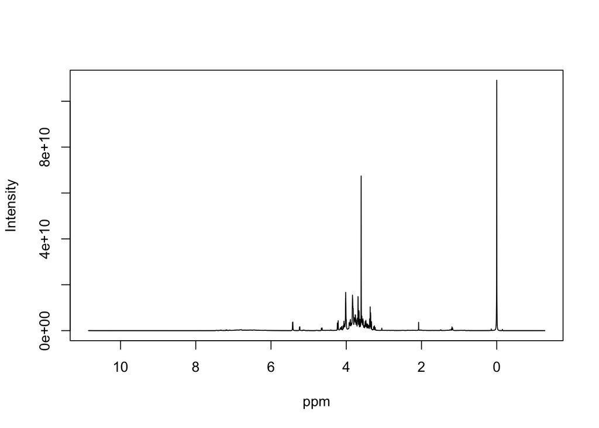

```r
# Plot single spectrum
spec(X[1,], ppm, shift = range(ppm), interactive = F)
```

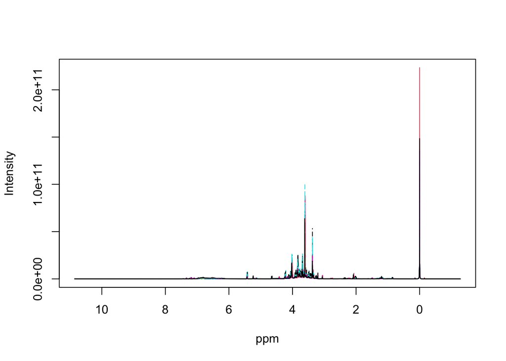

```r
# Plot multiple spectra
matspec(X, ppm, shift = range(ppm), interactive = F)
```

## Creating Run Order

Create a run order based on the acquisition date:

```r
meta$runOrder = rank(as.POSIXct(meta$a_DATE))
```

## TSP Signal Plotting

Overlay TSP signals while considering facets, colors, and line types:

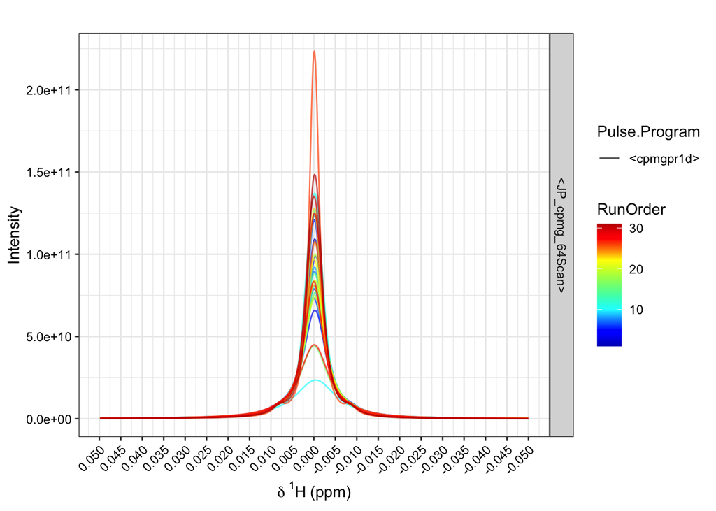

```r
specOverlay(X, ppm, shift=c(-0.05, 0.05),
            an=list('Facet'=meta$a_EXP,
                     'RunOrder'=meta$runOrder,
                     'Pulse Program'=meta$a_PULPROG))
```

## TSP Calibration

Perform TSP calibration and plot the calibrated spectra:

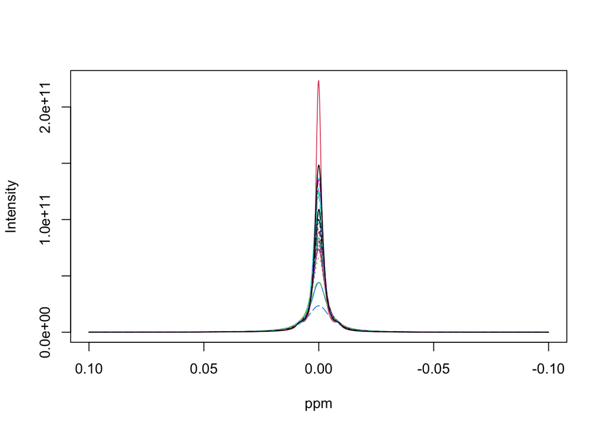

```r
X_cal = calibrate(X, ppm, type='tsp')
matspec(X_cal, ppm, shift=c(-0.1, 0.1), interactive=FALSE)
```

## Alignment of Peaks

Align the peaks in the spectra:

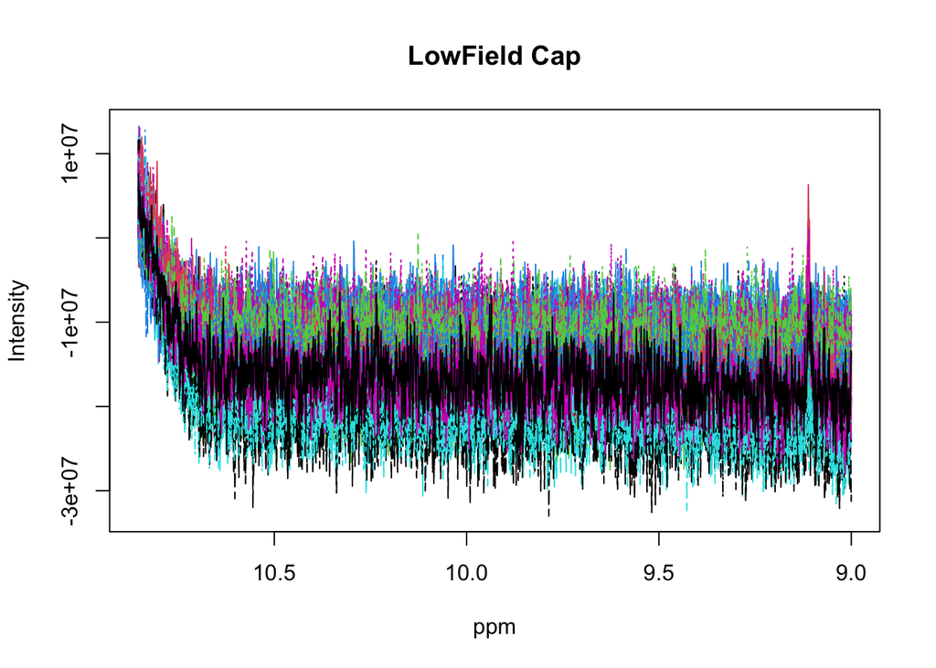

```r
Xal = alignSegment(X)
matspec(Xal, ppm, shift=c(9, 11), interactive=FALSE, main='LowField Cap')
```

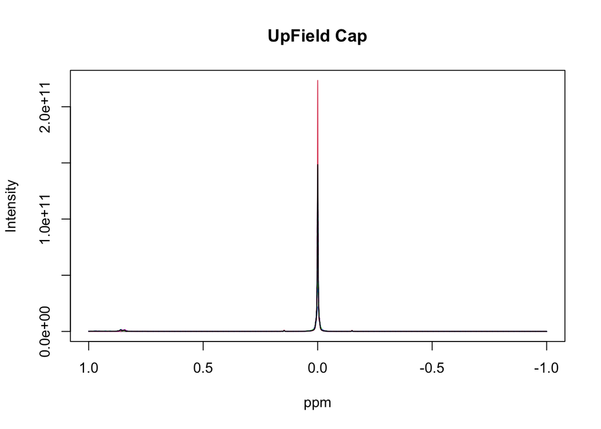

```r
matspec(Xal, ppm, shift=c(-1, 1), interactive=FALSE, main='UpField Cap')
```

## Indexing and Excision of Noise Regions

Identify TSP and noise regions, and excise them from the data:

```r
idx_tsp = get_idx(range=c(min(ppm), 1), ppm)
idx_noise = get_idx(range=c(9.5, max(ppm)), ppm)

idx_rm = c(idx_tsp, idx_noise)
X_cut = Xal[, -idx_rm]
ppm = ppm[-idx_rm]
```

## Baseline Correction

Apply baseline correction and compare the results visually:

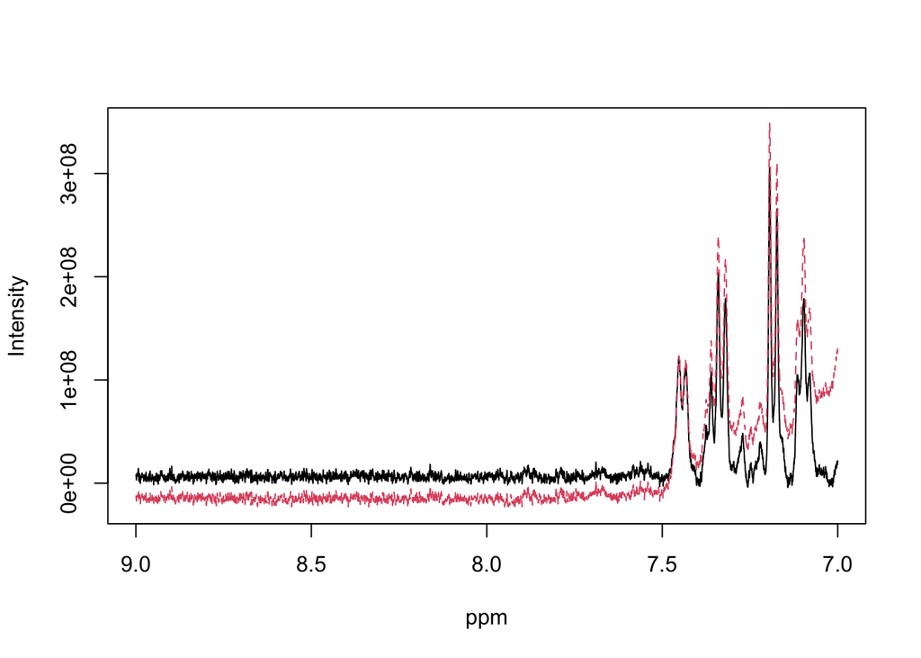

```r
X_bl = bcor(X_cut)
Xcompare = rbind(X_bl[1, ], X_cut[1, ])
matspec(Xcompare, ppm, shift=c(7, 9), interactive=FALSE)
```

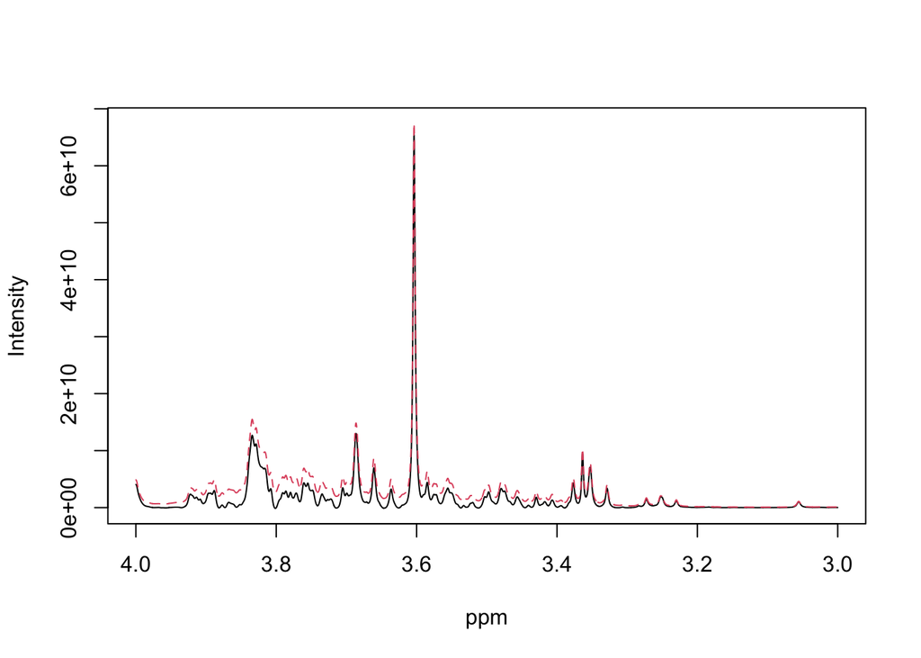

```r
matspec(Xcompare, ppm, shift=c(3, 4), interactive=FALSE)
```

## PQN Normalization

Perform PQN normalization and visualize the dilution coefficients:

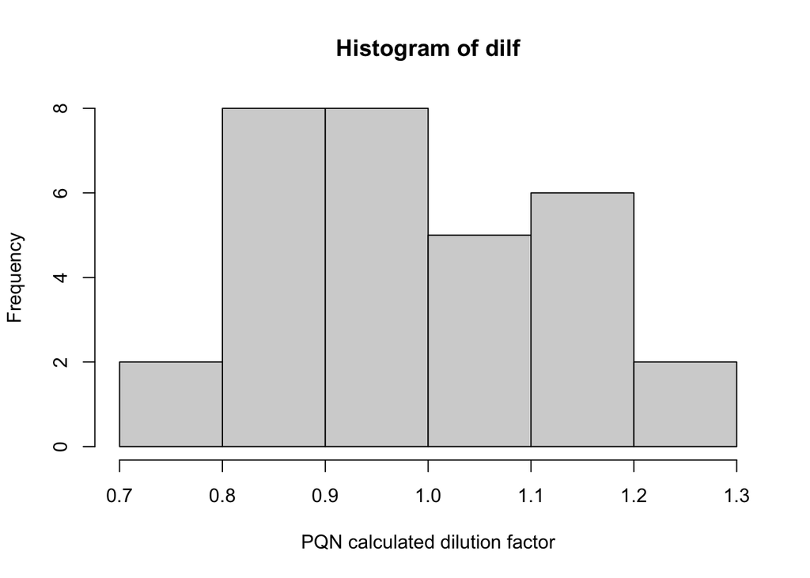

```r
X_pqn = pqn(X_bl, add_DilF = 'dilf')
hist(dilf, xlab='PQN calculated dilution factor')
```